## Strokes In Scotland Data Report

**How can Scottish health services most effectively prevent and treat stroke diagnoses?**

This project examines data on stroke diagnosis in Scotland in order to inform decision making on stroke care and intervention by public health bodies.

## Background

- Stroke is a disease of the cerebrovascular system, the system which supplies blood to the brain.
- Cerebrovascular disease include stroke, Subarachnoid Haemorhage or Transient Ischemic Attacks (commonly known as mini-strokes).
- The main preventable risk factors for stroke are smoking, high blood pressure, lack of exercise and a poor diet.
- The treatment and prevention of stroke is a national clinical priority for Scotland
- Scotland has launched major stroke care plans in 2009 and 2014.

## Data and Methodology

- This project uses publicly available published by Public Health Scotland
- Available data covers the years 2009-2018
- The data includes information on hospital activity (stays and discharges), mortality rates and incidence rates.
- Demographic detail varies by dataset and include age, gender, Council Area or Health Board and SIMD (Scottish Index of Multiple Deprivation)
- Data is cleaned, analysed and presented in R using Rstudio and Tidyverse.

## Key assumptions

- Financial year can be compared to calendar year without significantly undermining the analysis.
- Ambiguously named and defined crude rates in individual datasets refer to the crude rate of the dataset’s subject variable.
- Definition of all genders group varies with dataset, so it has been removed from analysis.
- NA, Other and Scotland are not useful values for measures by Health Board or Council Area and have been removed from analysis.
- Cerebrovascular Disease is not a catch-all for stroke, TIAs and SH and therefore contains useful information on unidentified diagnosis.

### How do mortality rates vary with diagnosis and demographics? Age

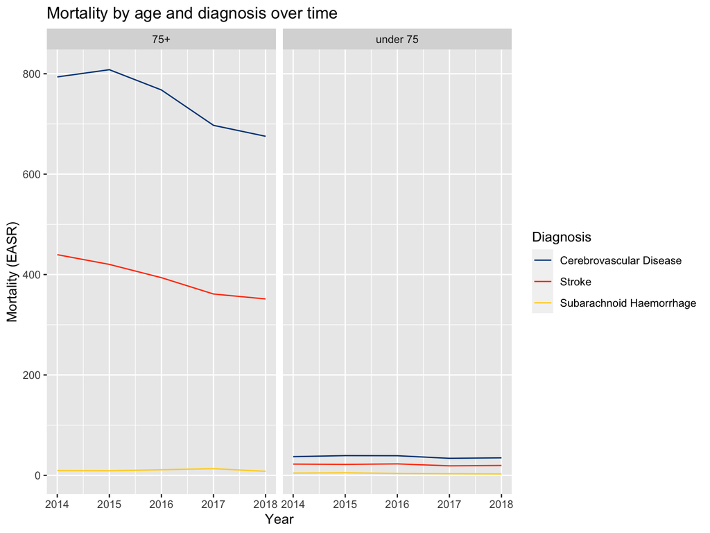

### How do mortality rates vary with diagnosis and demographics? Gender

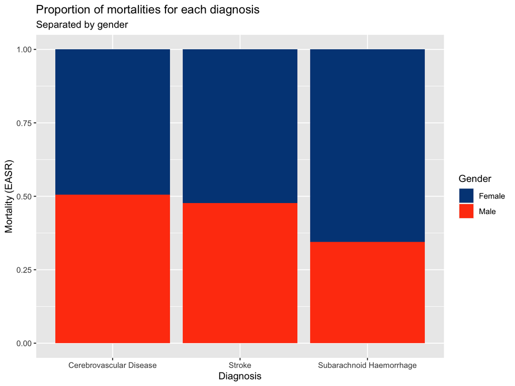

- Women die from Subarachnoid Haemorhage proportionally more than men.

### How do mortality rates vary with diagnosis and demographics? Age and Gender

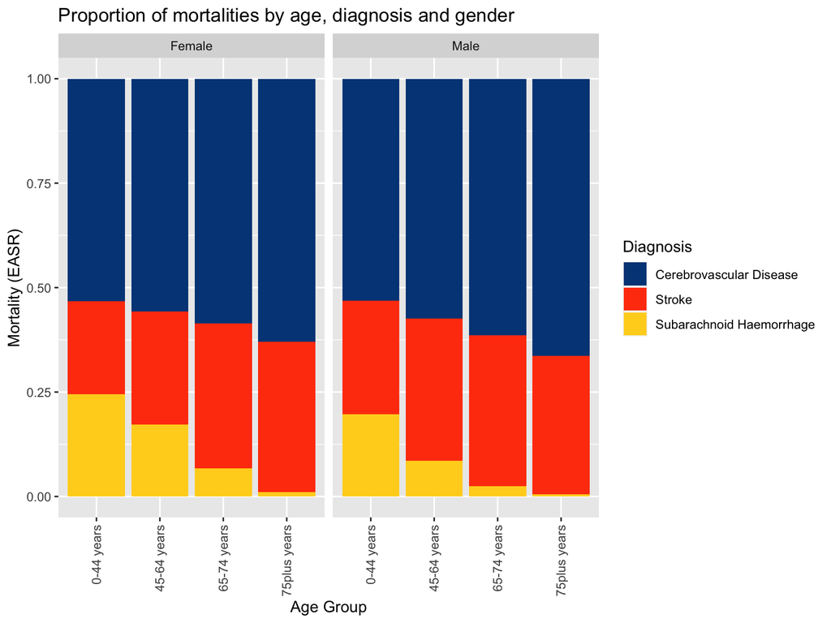

- Younger women with Subarachnoid Haemorhage are dying more often from Subarachnoid Haemorhage than males.
- Under 65, men have higher proportion of mortality by stroke than women

### How do stroke outcomes vary with demographics? Gender

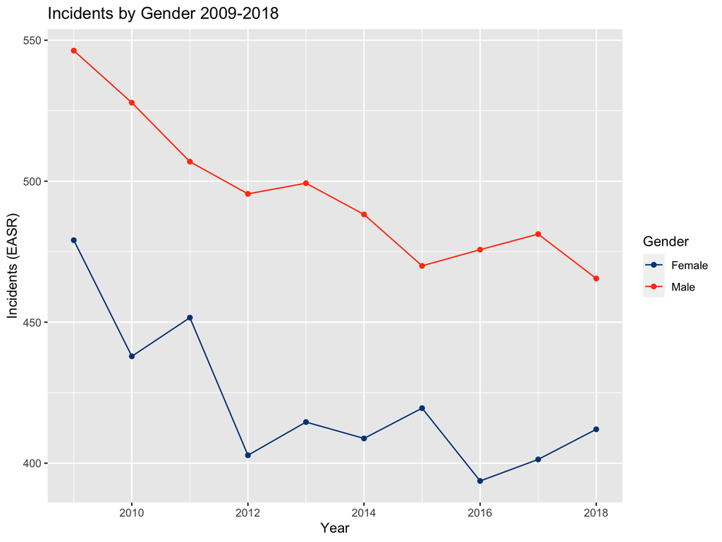

- Men have higher rates of incidence than women.
- Female incidence rates are the most volatile and have been rising since 2016.
- Although men have higher incidence rates than women, they have similar levels of mortality. i.e. more women die per episode of stroke diagnosis than men.

### How do stroke outcomes vary with demographics? Age

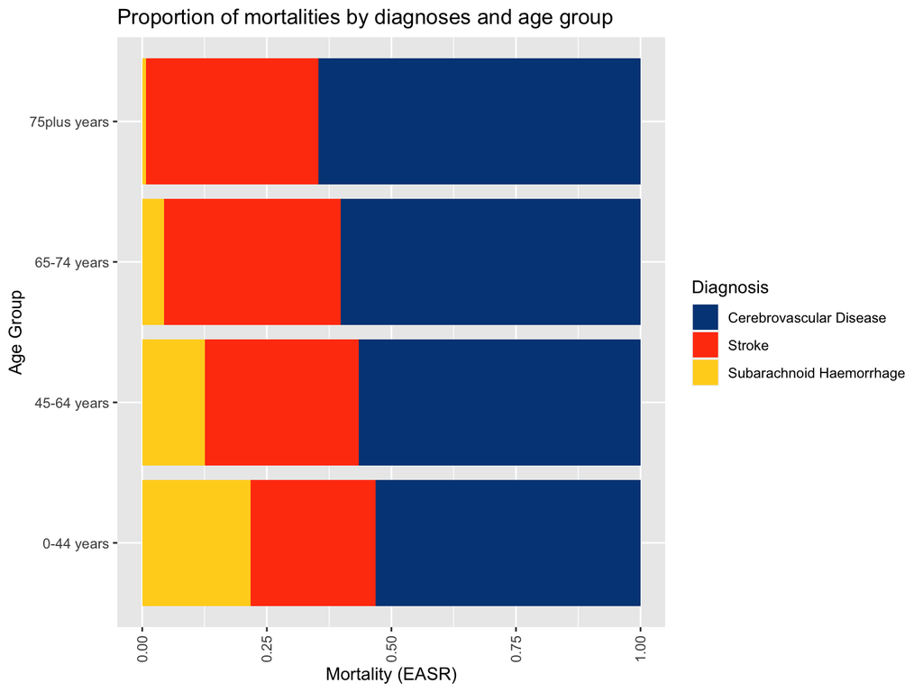

- Stroke discharges increase with age group, but account for consistent mortality proportion.
- CD is the highest killer for and proportion of deaths increases with age.
- SH causes a higher proportion of fatalities in younger age groups.

### How do stroke outcomes vary with demographics? Gender and Age

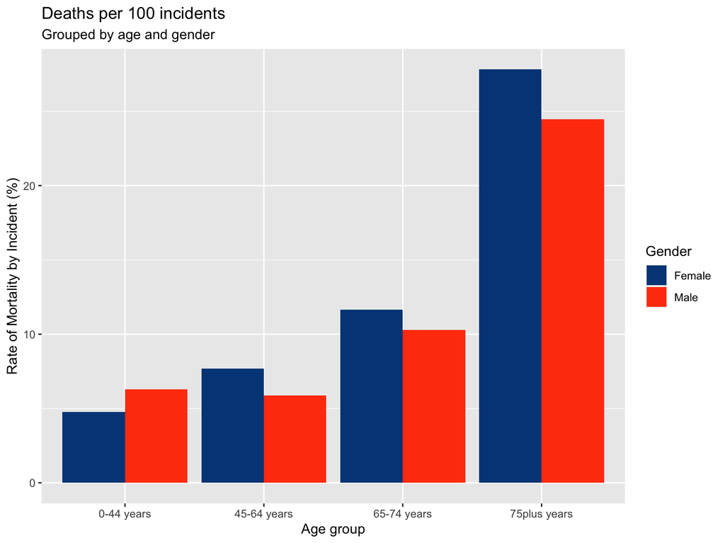

- Mortality rates: under 75 - men highest, over 75 women highest.
- Men have the highest incidence rates for all age groups.
- Deaths per incident: under 45 - men highest, over 45 - women highest.

### How do stroke outcomes vary with demographics? Healthboard

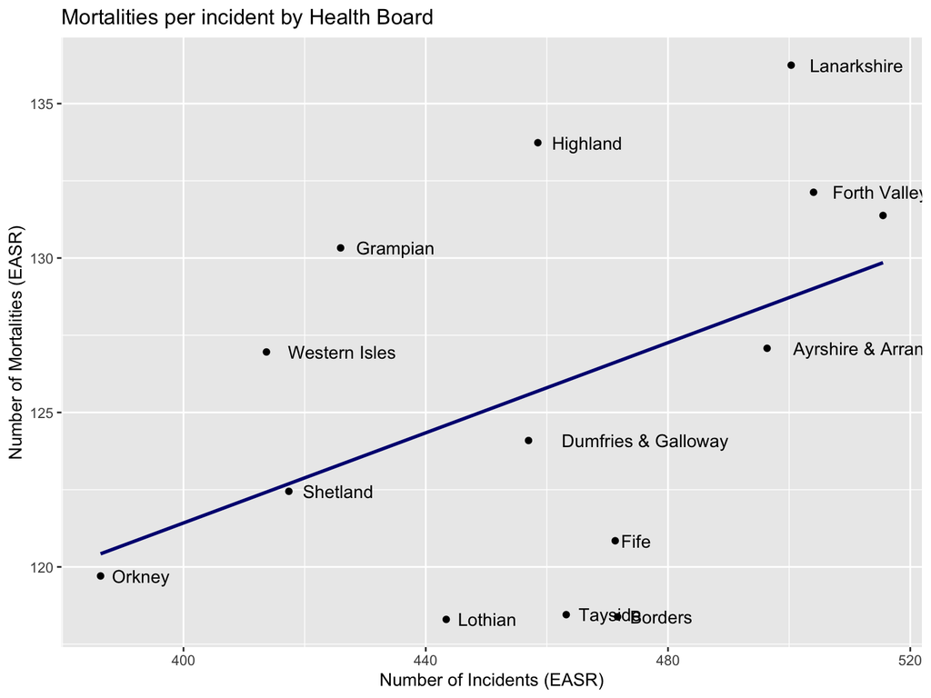

### How do stroke outcomes vary with demographics? Council

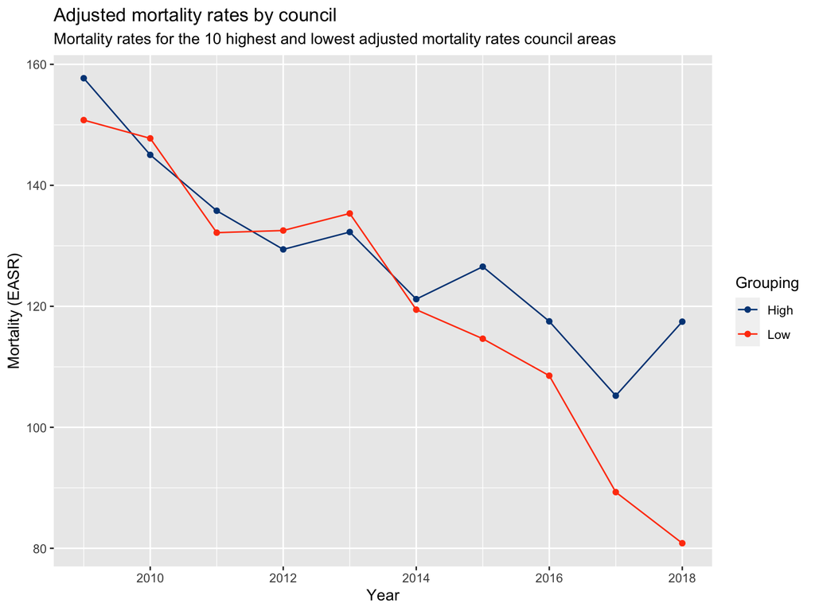

- Highest adjusted mortality in Inverclyde and Renfrewshire.
- Lowest adjusted mortality rates in East Renfrewshire and East Dunbartonshire.
- The 10 councils with the lowest recent mortality rates show much more stable decline.

### How do stroke outcomes vary with demographics? SIMD

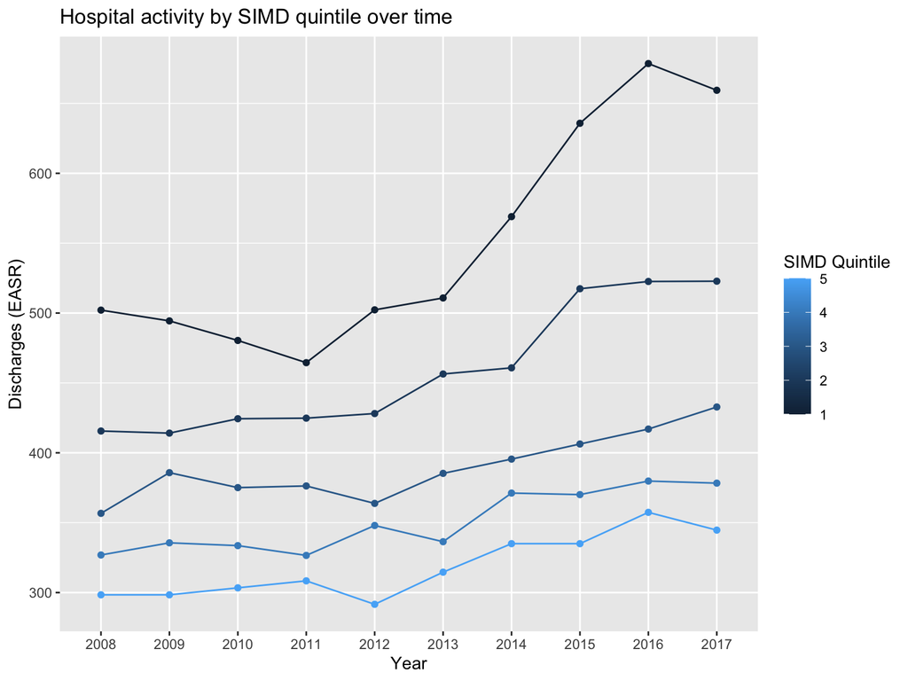

- Hospital activity increases with deprivation.
- Difference between hospital activity rates for deprivation quintiles is increasing over time, particularly for the 2 most deprived quintiles.

### How do stroke outcomes vary with demographics? SIMD

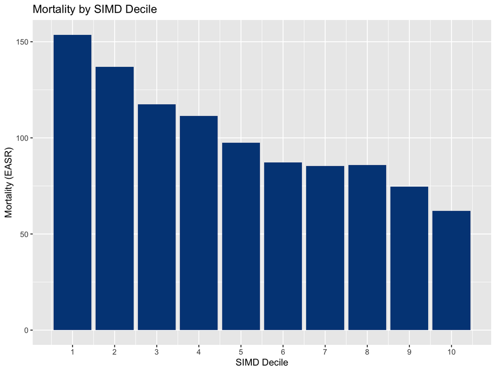

- Mortalities increase with deprivation.
- Chance of dying from stroke doubles from the least to the most deprived deciles.

### How do stroke outcomes vary with demographics? Age Group and SIMD

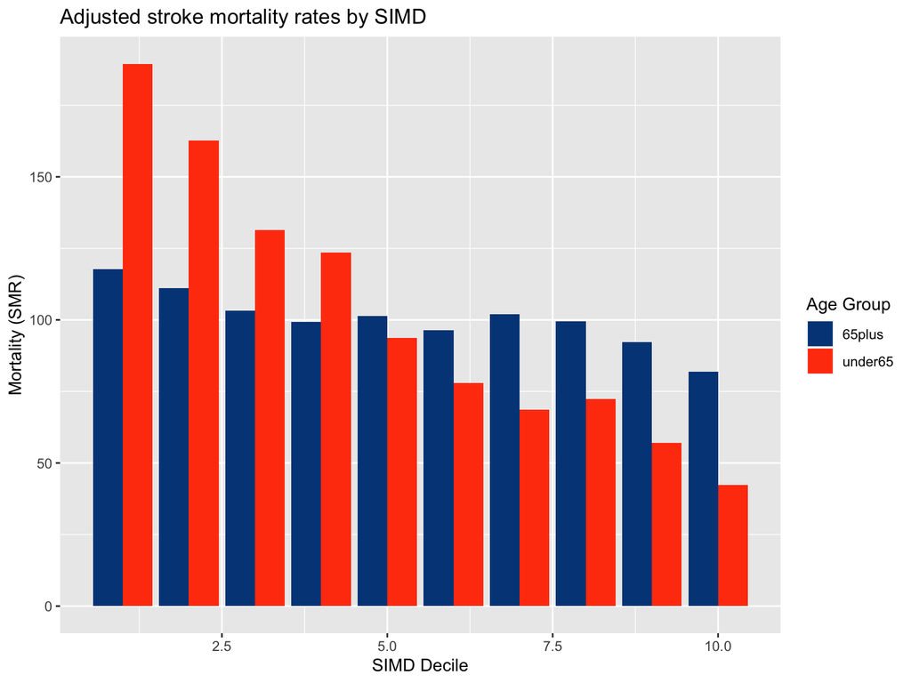

- SIMD has the highest impact on mortality for the under 65 age group.
- 189.5 people per 100,000 under 65 (adjusted) die of strokes in the most deprived decile, compared to just 42.3 of those in the least deprived decile.

### What measures have been successful in the treatment and prevention of stroke?

Direct answer unavailable in the available data, but useful information obtained

**Recommendations for future research:**

### Which demographics should we target for stroke intervention?

**Future research:**

- Explore data collection to find diagnosis which accounts for excess figures in CD diagnosis.
- Model social factors which contribute to stroke incidence and mortality, such as smoking, high blood pressure, caring duties, mental wellbeing.
- Compare diagnosis rates on presentation and discharge hospital to identify whether misdiagnosis of Subarachnoid Haemorhage is more common in women or younger age groups.
- Conduct research on the understanding and identification of Subarachnoid Haemorhage in women.
- Generate adjusted figures for hospital activity to explore hospital attendance by demographic.

**Recommended interventions:**

- Targetted interventions for women and younger people in deprived areas.
- Publicise stroke symptoms with an emphasis on women and hospital attendance

## Further information on data and methodology available on request